# Binary Logistic Regression in R

Clay Ford, UVA Library

To hide the output, click the Expand/Collapse output button. To clear results (or an error), click the “x”.

You can also press *Ctrl+Enter* (Win/Linux) or *Cmd+Return* (Mac) to run one line of code at a time (instead of the entire chunk).

Add a new R code chunk by clicking the *Insert Chunk* button on the toolbar or by pressing *Ctrl+Alt+I* (Win/Linux) or *Cmd+Option+I* (Mac).

## CODE ALONG 0

Enter a new code chunk and run the code `rbinom(n = 10, size = 1, prob = 0.5)` (sample 10 random values from a binomial distribution, ie flip a fair coin 10 times)

```r
rbinom(n = 10, size = 1, prob = 0.5)
```

## Load packages

We’ll use the following packages in this workshop.

```r
library(vcdExtra)
library(car)
library(effects)
library(ggeffects)
```

## Proportions and Probability

Pick a UVA student at random. What is the probability they have a tattoo? This is a *binary* response. Only two possible answers: yes or no. We don’t know, so we take a random sample. Let’s say we randomly sample 100 students and find that 15 students have tattoos.

The *proportion*, 15/100 = 0.15, can be interpreted as an estimated *probability* that a UVA student has a tattoo. Recall that proportions and probabilities range from 0 to 1. We might conclude about 15% of UVA students have tattoos, or there’s a probability of about 0.15 that a randomly selected UVA student has a tattoo.

What if we sampled 100 males and 100 females and compared the proportion with tattoos? Perhaps 0.18 of males have tattoos and 0.12 of females have tattoos. This suggests the probability of having a tattoo may be related to sex.

What if we also collected other information such as cumulative GPA or Greek life (yes or no)? Again this suggests the probability of having a tattoo may be related to multiple *variables* or *predictors*.

*Binary Logistic Regression* is a method that allows us to investigate questions such as this. It allows us to *model the probability* of a binary event given multiple predictors.

Statistical modeling boils down to 3 steps:

1. propose and fit a model
2. assess if model is good
3. use model to make predictions or quantify relationships

## Load Data for the workshop

Today we’ll work with data on Intensive Care Unit (ICU) admissions. This data are a sample of 200 subjects who were part of a much larger study on survival of patients following admission to an adult ICU, derived from Hosmer, Lemeshow and Sturdivant (2013) and included with the vcdExtra package, Friendly (2022).

```r
icu <- readRDS(file = "data/icu.rds")
names(icu)
```

```
[1] "died"     "age"      "sex"      "cancer"   "systolic" "admit"
[7] "ph"       "pco"      "uncons"
```

The goal today is to teach the basics of Binary Logistic Regression by developing a model to predict the probability of survival after admission to this ICU and to study the risk factors associated with ICU mortality.

### List of variables

- died: Died before discharge? (No or Yes)
- age: Patient age
- sex: Patient sex (Female or Male)
- cancer: Cancer part of present problem? (No or Yes)
- systolic: Systolic blood pressure at admission (mm Hg)
- admit: Type of admission (Elective or Emergency)
- ph: pH from initial blood gases (>=7.25 or <7.25)
- pco: partial pressure of carbon dioxide (PCO2) (<=45 or >45)
- uncons: patient unconscious at admission? (No or Yes)

## Explore the ICU Data

The response variable is “died”. Let’s count the responses using the `xtabs()` function. The argument `addNA = TRUE` reports missing values if any are present.

```r
xtabs(~ died, data = icu, addNA = TRUE)
```

```
died
 No Yes
160  40
```

We can get the proportion of each category by using the `proportions()` function. Notice we can “pipe” the result of `xtabs()` into `proportions()` using the base R pipe operator, `|>`

```r
xtabs(~ died, data = icu) |> proportions()
```

```
died
 No Yes
0.8 0.2
```

Just based on this information, a naive estimate of the probability of death (Yes) after admission to the ICU is about 20%. But this probability estimate may change based on other predictors such as patient age, sex, whether or not patient was conscious at ICU admission, etc.

How does being unconscious at time of admission to ICU affect proportion of deaths? This time we use `xtabs()` to create a cross tabulation, and then pipe into `proportions()` with `margin = 1` to specify we want to calculate proportions for the rows. In other words, find proportion of `died` conditional on `uncons`. Of those who were unconscious at admission about 87% died. But only 15 out of 200 people were unconscious at admission.

```r
xtabs(~ uncons + died, data = icu) |>
  proportions(margin = 1) |>
  round(3)
```

```
      died
uncons    No   Yes
   No  0.854 0.146
   Yes 0.133 0.867
```

How does age relate to the proportion of died? Plotting a factor as a function of a numeric variable using `plot()` creates a *spineplot*. The x-axis groups age into categories. Each vertical box shows the proportion of died within each age category. The width of the box corresponds to the proportion of age categories. Age 60 - 70 appears to be the largest group. It appears the proportion of deaths creeps up with increasing age.

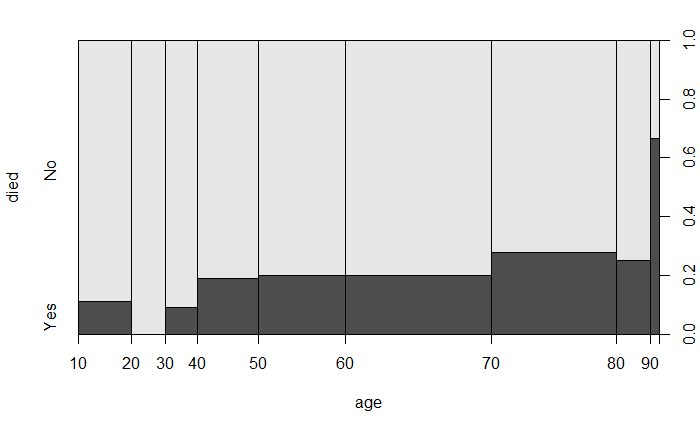

## CODE ALONG 1

- create a cross tabulation of admit and died
- Plot `died` as a function of `systolic`.

## Binary Logistic Regression basics

Binary logistic regression produces a *model* that we can use to make probability predictions or quantify relationships. For example, with the ICU data we might…

- predict probability of death given age, sex, and whether you were unconscious at admission
- determine how much the probability of dying increases (or decreases) if you were unconscious at admission

*We are responsible for proposing and assessing the model*! For example, the “sex” variable may or may not help our model. We have to decide to retain it or drop it. Subject matter expertise is just as important as statistical expertise.

One way to fit binary logistic regression models in R is with the `glm()` function. GLM = Generalized Linear Model.

Let’s fit a model. Notice we must set `family = binomial` because our response is binary. We almost always want to save the model result. The formula says “model `died` as a function of `age`, `sex`, and `uncons`.” Call `summary()` on the model object to see the result.

```r
m <- glm(died ~ age + sex + uncons, data = icu, family = binomial)
summary(m)
```

```
Call:
glm(formula = died ~ age + sex + uncons, family = binomial, data = icu)

Deviance Residuals:
    Min       1Q   Median       3Q      Max
-2.2875  -0.6232  -0.5190  -0.3227   2.4303

Coefficients:
            Estimate Std. Error z value Pr(>|z|)
(Intercept) -3.58028    0.89402  -4.005 6.21e-05 ***
age          0.02831    0.01231   2.300   0.0214 *
sexMale      0.14282    0.42499   0.336   0.7368
unconsYes    3.60081    0.79514   4.529 5.94e-06 ***
---
Signif. codes:  0 ‘***’ 0.001 ‘**’ 0.01 ‘*’ 0.05 ‘.’ 0.1 ‘ ’ 1

(Dispersion parameter for binomial family taken to be 1)

    Null deviance: 200.16  on 199  degrees of freedom
Residual deviance: 159.36  on 196  degrees of freedom
AIC: 167.36

Number of Fisher Scoring iterations: 5
```

The model is in the Estimate column of the coefficients section. Here’s the model expressed in basic math notation:

$$\text{died} = -3.58 + 0.02\text{ age} +
0.14\text{ sex} + 3.60\text{ uncons}$$

If we plug in values for `age`, `sex`, and `uncons` we get *predicted log odds* of dying, not probability.

Log odds are also known as *logit* values. The logit transformation takes probability, which ranges from [0,1], and expresses it as log odds, which ranges from [-Inf,+Inf]. This is desirable since modeling probability directly could produce predictions below 0 or above 1.

Let’s make a prediction for a male age 70 who was unconscious at admission. We use the `predict()` function with a data frame containing our predictors.

```r
predict(m, newdata = data.frame(age = 70, sex = "Male", uncons = "Yes"))
```

```
       1
2.145336
```

The prediction, 2.145, is hard to interpret. To get probability we need to take the *inverse logit*, which converts log odds back to the probability scale. Fortunately we can just set `type = "response"` in the `predict()` function.

```r
predict(m, newdata = data.frame(age = 70, sex = "Male", uncons = "Yes"),
        type = "response")
```

```
        1
0.8952322
```

We predict a very high probability of dying given you’re a 70 year old male who was unconscious at admission to the ICU.

Again we should assess this model and think carefully before we fall in love with our prediction!

## Probability versus Odds versus Log Odds

Let p be probability. Odds equal p/(1-p).  
Log odds is log(odds).

Let’s convert a few probabilities to odds and log odds. The function `fractions()` from the MASS package returns fractions, which is usually how odds are expressed. We use `as.character()` to print the fraction bar.

| p | odds | logodds |
| --- | --- | --- |
| 0.001 | 1/999 | -6.9067548 |
| 0.010 | 1/99 | -4.5951199 |
| 0.100 | 1/9 | -2.1972246 |
| 0.300 | 3/7 | -0.8472979 |
| 0.500 | 1 | 0.0000000 |
| 0.700 | 7/3 | 0.8472979 |
| 0.900 | 9 | 2.1972246 |
| 0.990 | 99 | 4.5951199 |
| 0.999 | 999 | 6.9067548 |

R has built-in functions for converting probability to log odds and log odds to probability.

- `plogis`: convert log odds to probability
- `qlogis`: convert probability to log odds

Convert log odds of 2 to probability.

```r
plogis(2)
```

```
[1] 0.8807971
```

Convert probability of 0.8807971 to log odds.

```r
qlogis(0.8807971)
```

```
[1] 2
```

You probably don’t need these functions when doing logistic regression in R, but they can be useful to know.

## How to interpret coefficients

Our model is comprised of simple additive predictors (ie, *main effects*). Therefore the coefficients can be interpreted. We can use the `coef()` function to extract the coefficients.

```r
coef(m)
```

```
(Intercept)         age     sexMale   unconsYes
-3.58027565  0.02831407  0.14281723  3.60081020
```

Again these coefficients are on the log odds scale. If we exponentiate them we get *odds ratios*. An odds ratio is a ratio of two odds.

Let’s say an event has a probability of 0.8 of happening. The corresponding odds are 4, or 4 to 1. We can expect 4 “successes” for every one “failure”.

```r
# event 1
p1 <- 0.8
odds1 <- p1/(1-p1)
odds1
```

```
[1] 4
```

Let’s say another event has a probability of 0.6 of happening. The corresponding odds are 1.5.

```r
# event 2
p2 <- 0.6
odds2 <- p2/(1-p2)
odds2  # 3/2
```

```
[1] 1.5
```

The odds ratio of the two events is 4/1.5, which is about 2.7.

```r
odds1/odds2
```

```
[1] 2.666667
```

This says the odds of event 1 are about 2.7 times higher than the odds of event 2.

Let’s look at the odds ratios of our model:

```r
exp(coef(m))
```

```
(Intercept)         age     sexMale   unconsYes
 0.02786802  1.02871872  1.15351895 36.62789836
```

Our model claims the odds of dying when unconscious are about 36 times higher than the odds of dying when you are not unconscious. We can calculate this “by hand” by predicting probabilities for two people, one who was unconscious and the other who was not:

```r
p1 <- predict(m, newdata = data.frame(age = 60, sex = "Male",
                                      uncons = "Yes"),
              type = "response")
p2 <- predict(m, newdata = data.frame(age = 60, sex = "Male",
                                      uncons = "No"),
              type = "response")
# odds ratio
or <- (p1/(1-p1)) / (p2/(1-p2))
cbind(p1, p2, or)
```

```
         p1       p2      or
1 0.8655527 0.149489 36.6279
```

The odds ratio for age is about 1.03. This says the odds of dying increase about 3% for every 1 year increase in age. If we wanted to estimate that for every 10 years increase in age, we simply multiply the coefficient by 10.

```r
exp(coef(m)["age"] * 10)
```

```
     age
1.327292
```

Every 10 year increase in age increases the odds of dying by about 33%.

## Standard errors and hypthesis tests

If we use `coef()` on `summary()` we extract the coefficient table which contains standard errors, test statistics (z value), and p-values.

- Std. Error: quantifies uncertainty of estimated coefficient. It may help to imagine adding and subtracting it to your estimate to get an idea of the variability of your estimate.
- z value: Ratio of Estimate to Std. Error. Large ratios mean coefficients with relatively small standard errors. z values larger than 3 are usually considered “big”.
- Pr(>|z|): probability of getting a z value as big or bigger if coefficient is 0, given other predictors already in model.

Altogether this information is used to assess whether predictor coefficients are reliably positive or negative (ie, different from 0)

```r
coef(summary(m)) |> round(3)
```

```
            Estimate Std. Error z value Pr(>|z|)
(Intercept)   -3.580      0.894  -4.005    0.000
age            0.028      0.012   2.300    0.021
sexMale        0.143      0.425   0.336    0.737
unconsYes      3.601      0.795   4.529    0.000
```

Another way to assess direction and magnitude of coefficients is with confidence intervals. Use `confint()` on the model object.

```r
confint(m) |> round(3)
```

```
             2.5 % 97.5 %
(Intercept) -5.509 -1.978
age          0.006  0.054
sexMale     -0.677  1.003
unconsYes    2.230  5.503
```

We’re not sure if being Male increases or decreases the chance of dying. The lower bound is negative and the upper bound is positive.

Using `exp()` with `confint()` provides a confidence interval on the odds ratios. Of interest here is whether or not the CI crosses 1. A ratio of 1 implies no difference in odds.

```r
exp(confint(m)) |> round(3)
```

```
            2.5 %  97.5 %
(Intercept) 0.004   0.138
age         1.006   1.056
sexMale     0.508   2.727
unconsYes   9.296 245.415
```

## Code along 2

- Model died as a function of age, cancer, admit and uncons. Save the model as `m2`.
- Use `summary()` and `confint()` on the model
- Interpret the coefficient for admit as an odds ratio
- What’s the predicted probability of dying for a person age 50 with cancer, Emergency admission, and unconscious?

```r
m2 <- glm(died ~ age + cancer + admit + uncons, data = icu,
          family = binomial)
summary(m2)
```

```
Call:
glm(formula = died ~ age + cancer + admit + uncons, family = binomial,
    data = icu)

Deviance Residuals:
    Min       1Q   Median       3Q      Max
-2.5631  -0.6241  -0.3253  -0.1487   2.4928

Coefficients:
               Estimate Std. Error z value Pr(>|z|)
(Intercept)    -6.86978    1.31882  -5.209 1.90e-07 ***
age             0.03718    0.01277   2.911 0.003600 **
cancerYes       2.09711    0.83847   2.501 0.012381 *
admitEmergency  3.10218    0.91860   3.377 0.000733 ***
unconsYes       3.70546    0.87647   4.228 2.36e-05 ***
---
Signif. codes:  0 ‘***’ 0.001 ‘**’ 0.01 ‘*’ 0.05 ‘.’ 0.1 ‘ ’ 1

(Dispersion parameter for binomial family taken to be 1)

    Null deviance: 200.16  on 199  degrees of freedom
Residual deviance: 139.13  on 195  degrees of freedom
AIC: 149.13

Number of Fisher Scoring iterations: 6
```

```r
confint(m2)
```

```
                    2.5 %      97.5 %
(Intercept)    -9.7539194 -4.52734559
age             0.0137240  0.06421055
cancerYes       0.4612548  3.86281221
admitEmergency  1.5316242  5.22915253
unconsYes       2.2028064  5.77725756
```

```r
predict(m2, newdata = data.frame(age = 50, cancer = "Yes",
                                 admit = "Emergency", uncons = "Yes"),
        type = "response")
```

## Model assessment

It’s easy to use `glm()` to fit a binary logistic model, but is the model “good”? Is one model better than another? How do we know which predictors to keep and which ones to drop? Should we allow interactions or non-linear transformations? *Model building is hard* and requires equal parts statistical expertise and subject matter expertise.

One question to consider: *is our model better than the NULL model*, where the NULL model is simply the proportion of “successes”. Recall 20% of the patients admitted to the ICU died.

```r
# proportion of died = "Yes"
mean(icu$died == "Yes")
```

```
[1] 0.2
```

The NULL model is simply predicting anyone admitted to the ICU has a 20% chance of dying. This is sometimes called the *intercept-only model*, which we can fit as follows:

```r
# died ~ 1 is the intercept-only model
m0 <- glm(died ~ 1, data = icu, family = binomial)
coef(m0)
```

```
(Intercept)
  -1.386294
```

The intercept coefficient is the predicted *log odds* of dying. We can convert log odds to probability using the inverse logit, which is available as the `plogis()` function:

```r
# convert log odds to probability
plogis(coef(m0))
```

```
(Intercept)
        0.2
```

We can formally assess if a proposed model is better than the NULL model using the `anova()` function. Recall our model `m`

```r
formula(m)
```

```
died ~ age + sex + uncons
```

How much better is it than the NULL model? Call `anova()` with `test = "Chisq"`:

```r
anova(m, test = "Chisq")
```

```
Analysis of Deviance Table

Model: binomial, link: logit

Response: died

Terms added sequentially (first to last)

       Df Deviance Resid. Df Resid. Dev Pr(>Chi)
NULL                     199     200.16
age     1    7.855       198     192.31 0.005069 **
sex     1    0.001       197     192.31 0.975723
uncons  1   32.941       196     159.37  9.5e-09 ***
---
Signif. codes:  0 ‘***’ 0.001 ‘**’ 0.01 ‘*’ 0.05 ‘.’ 0.1 ‘ ’ 1
```

Notice that terms are added sequentially, *in order*. This is sometimes called a *Type I test*.

- A model with just age appears to be better than the NULL model.
- Adding sex with age already in the model doesn’t seem to make any further improvement.
- Adding uncons with age and sex already in the model further improves the model quite a bit. Notice the drop in *Residual Deviance*.

Deviance is a *statistical summary of model fit*. A “good” predictor should drop Residual Deviance by more than 1. Notice sex produces no change in deviance, but uncons drops it more than 30.

An alternative to Type I tests are *Type II tests*, which test the contribution of each variable assuming all others are included. The `Anova()` function from the car package produces Type II tests. This technically does not compare the model to the NULL model. However it does allow us to asses each variable’s contribution to the model.

```r
Anova(m)
```

```
Analysis of Deviance Table (Type II tests)

Response: died
       LR Chisq Df Pr(>Chisq)
age       6.189  1    0.01286 *
sex       0.114  1    0.73584
uncons   32.941  1    9.5e-09 ***
---
Signif. codes:  0 ‘***’ 0.001 ‘**’ 0.01 ‘*’ 0.05 ‘.’ 0.1 ‘ ’ 1
```

The substance of the results are largely the same, however each test assumes the other variables are in the model. For example, adding age to a model with sex and uncons already present appears to improve the model.

A second question to consider: *how bad is our model compared to a saturated model that fits the data perfectly*? The `LRstats()` function from the vcdExtra package helps us to assess this question. It conducts a hypothesis test with the Null being “the model fit is no different from the saturated model”. A low p-value provides evidence against this hypothesis.

```r
LRstats(m)
```

```
Likelihood summary table:
     AIC    BIC LR Chisq  Df Pr(>Chisq)
m 167.37 180.56   159.37 196     0.9742
```

The result of this test fails to provide evidence against the Null.

## Code along 3

Assess model `m2` using the methods we just described.

```r
anova(m2, test = "Chisq")
```

```r
LRstats(m)
```

## Fitting more complex models

So far our models only contain *main effects*. The effects are *additive*. It doesn’t matter what age you are, the effect of uncons is the same. The effect of age is also constant. The effect of age going from 20 to 21 is the same as the age going from 75 to 76.

We can relax that assumption by allowing variables to *interact* and to allow variables to have *non-linear* effects. These make our models more complex and more difficult to interpret. But they also may produce better models that more accurately explain the probability of our response.

### Interactions

When variables interact, that means we cannot untangle their effects. The effect of one depends on another. For example, perhaps the effect of age depends on uncons status.

Below we allow age and uncons to interact by adding `age:uncons` to the model. That does not mean they really interact. We’re simply *allowing them to interact in our model*. The evidence for the hypothesized interaction seems rather week according to the small z value and relatively high p-value.

```r
m_int <- glm(died ~ age + sex + uncons + age:uncons, data = icu,
             family = binomial)
summary(m_int)
```

```
Call:
glm(formula = died ~ age + sex + uncons + age:uncons, family = binomial,
    data = icu)

Deviance Residuals:
    Min       1Q   Median       3Q      Max
-2.3997  -0.6288  -0.5046  -0.2926   2.5065

Coefficients:
              Estimate Std. Error z value Pr(>|z|)
(Intercept)   -3.82062    0.94408  -4.047 5.19e-05 ***
age            0.03235    0.01298   2.493   0.0127 *
sexMale        0.10896    0.42879   0.254   0.7994
unconsYes     12.29402    5.88994   2.087   0.0369 *
age:unconsYes -0.12999    0.08196  -1.586   0.1127
---
Signif. codes:  0 ‘***’ 0.001 ‘**’ 0.01 ‘*’ 0.05 ‘.’ 0.1 ‘ ’ 1

(Dispersion parameter for binomial family taken to be 1)

    Null deviance: 200.16  on 199  degrees of freedom
Residual deviance: 156.16  on 195  degrees of freedom
AIC: 166.16

Number of Fisher Scoring iterations: 5
```

### Non-linear effects

A non-linear effect is not constant. The slope or trajectory changes over the range of values. For example, humans don’t grow in height at a constant rate. We don’t grow 3 inches per year until we die. We tend to grow at varying rates until we stop in our late teens or 20s.

Below we allow age to have a non-linear effect by fitting a 2nd-degree polynomial using `poly(age, 2)`.

```r
m_poly <- glm(died ~ poly(age, 2) + sex + uncons, data = icu,
             family = binomial)
summary(m_poly)
```

```
Call:
glm(formula = died ~ poly(age, 2) + sex + uncons, family = binomial,
    data = icu)

Deviance Residuals:
    Min       1Q   Median       3Q      Max
-2.4535  -0.5969  -0.4812  -0.3694   2.2644

Coefficients:
              Estimate Std. Error z value Pr(>|z|)
(Intercept)    -1.9717     0.3592  -5.489 4.03e-08 ***
poly(age, 2)1   7.0066     3.3581   2.086   0.0369 *
poly(age, 2)2   2.5760     2.9586   0.871   0.3839
sexMale         0.1815     0.4288   0.423   0.6720
unconsYes       3.7115     0.8102   4.581 4.63e-06 ***
---
Signif. codes:  0 ‘***’ 0.001 ‘**’ 0.01 ‘*’ 0.05 ‘.’ 0.1 ‘ ’ 1

(Dispersion parameter for binomial family taken to be 1)

    Null deviance: 200.16  on 199  degrees of freedom
Residual deviance: 158.63  on 195  degrees of freedom
AIC: 168.63

Number of Fisher Scoring iterations: 5
```

It’s hard to tell if the polynomial is necessary. One way to assess this is using the `Anova()` function from the car package.

```r
Anova(m_poly)
```

```
Analysis of Deviance Table (Type II tests)

Response: died
             LR Chisq Df Pr(>Chisq)
poly(age, 2)    6.921  2    0.03142 *
sex             0.181  1    0.67045
uncons         33.668  1  6.537e-09 ***
---
Signif. codes:  0 ‘***’ 0.001 ‘**’ 0.01 ‘*’ 0.05 ‘.’ 0.1 ‘ ’ 1
```

It looks like it may be worth modeling age as a non-linear effect.

## Visualizing models

Adding interactions and/or non-linear terms make model interpretation extremely difficult. One way to make sense of your model is to use *effect displays*, or *effect plots*.

The basic idea is to pick a variable of interest, say age, and make predictions for it over a range of values while holding other predictors constant.

Below we show two ways to do this using the effects and ggeffects packages.

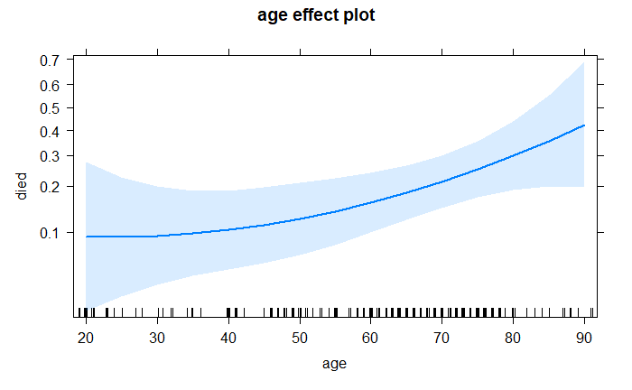

```r
Effect("age", mod = m_poly) |> plot()
```

We can make a similar plot using `ggpredict()` from the ggeffects package. Again we can pipe the result into `plot()`. The main difference is that ggeffects uses ggplot2 to create the plots.

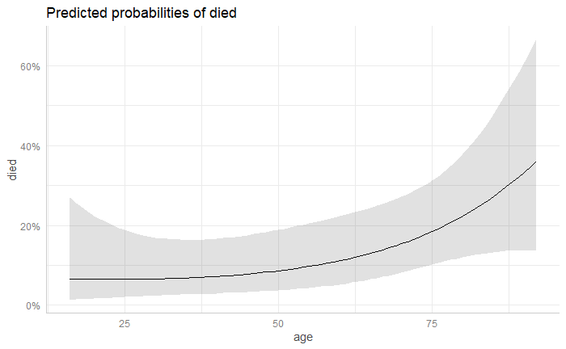

```r
ggpredict(model = m_poly, terms = "age") |> plot()
```

Another difference between `Effect()` and `ggpredict()` is what values the other predictors are held fixed at.

That’s why the position of the curve is different in the plots, though more importantly, *the shape is the same*.

Next, we visualize m_int which models an interaction between age and uncons. This allows the effect of uncons to depend on age, and vice versa. Using `Effect()`, we specify both variables as the focal predictors. The first variable will be plotted on the x-axis.

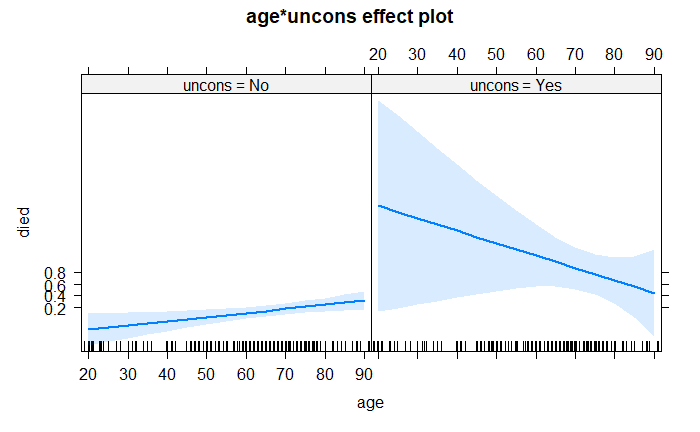

```r
Effect(focal.predictors = c("age", "uncons"), mod = m_int) |>
  plot()
```

There is a great deal of uncertainty about the effect of age when a patient is unconscious. That’s because of the 200 patients, only 15 were admitted unconscious. And no one under the age of 40 was unconscious when admitted to the ICU.

We create the same plot using `ggpredict()` with a vector of predictors as well. Notice this plot looks much different!

```
Data were 'prettified'. Consider using `terms="age [all]"` to get smooth plots.
```

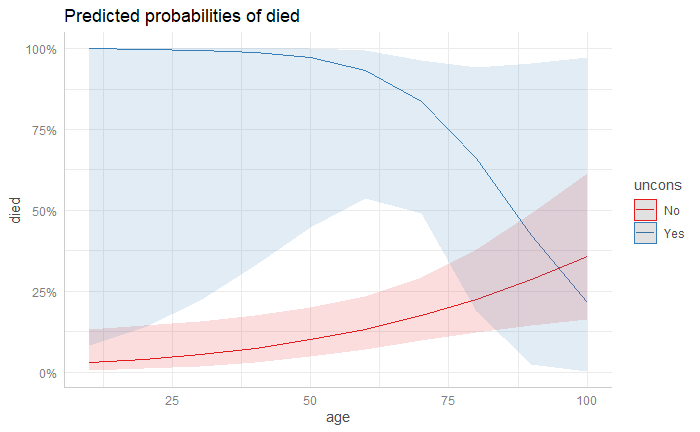

```r
ggpredict(model = m_int, terms = c("age", "uncons")) |>
  plot()
```

The `Effect()` plot is on the log odds scale, but labeled with probability. The `ggpredict()` plot is on the probability scale.

## Code Along 4

Fit a new model with the following formula and save as `m5`. (Systolic is the systolic blood pressure at admission)

`died ~ age + cancer + admit + uncons + systolic + age:systolic`

Does the interaction seem necessary? Visualize the interaction.

```r
Anova(m5)
```

```
Analysis of Deviance Table (Type II tests)

Response: died
             LR Chisq Df Pr(>Chisq)
age           10.0005  1   0.001565 **
cancer         6.7993  1   0.009120 **
admit         16.7252  1  4.320e-05 ***
uncons        28.0386  1  1.189e-07 ***
systolic       3.5231  1   0.060519 .
age:systolic   4.7698  1   0.028963 *
---
Signif. codes:  0 ‘***’ 0.001 ‘**’ 0.01 ‘*’ 0.05 ‘.’ 0.1 ‘ ’ 1
```

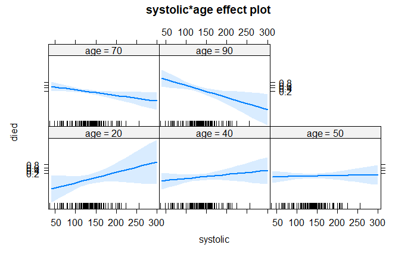

```r
Effect(c("systolic", "age"), mod = m5) |> plot()
```

## Comparing models

We can compare models by using criteria such as AIC and BIC as well as hypothesis tests. Let’s review both.

AIC and BIC are statistics for measuring goodness of fit. In isolation these values are not meaningful, but when compared for different models with the same response, *lower values are better*. The `LRstats` function shows both criteria. Let’s compare models `m` and `m2`:

```r
LRstats(m, m2)
```

```
Likelihood summary table:
      AIC    BIC LR Chisq  Df Pr(>Chisq)
m  167.37 180.56   159.37 196     0.9742
m2 149.13 165.63   139.13 195     0.9991
```

Even though both models appear to be just as good as a saturated model, `m2` appears to better than `m`.

When one model is *nested* in another, we can use hypothesis tests to assess whether the simpler model is just as good as the more complex model. Let’s fit two models, one nested in the other.

Model 1: age and uncons  
Model 2: age, uncons and their interaction

Model 2 says the effect of age depends on uncons and vice versa. Model 1 is nested within Model 2 since it’s a special case of Model 2 with an interaction coefficient of 0.

```r
m3 <- glm(died ~ age + uncons, data = icu, family = binomial)
m4 <- glm(died ~ age + uncons + age:uncons, data = icu, family = binomial)
```

Now we can carry out a formal test to compare the models using the `anova()` function. The null hypothesis is both models fit equally well. A low p-value provides evidence against the null.

```r
anova(m3, m4, test = "Chisq")
```

```
Analysis of Deviance Table

Model 1: died ~ age + uncons
Model 2: died ~ age + uncons + age:uncons
  Resid. Df Resid. Dev Df Deviance Pr(>Chi)
1       197     159.48
2       196     156.23  1   3.2516  0.07135 .
---
Signif. codes:  0 ‘***’ 0.001 ‘**’ 0.01 ‘*’ 0.05 ‘.’ 0.1 ‘ ’ 1
```

The interaction may be useful but is probably small. Whether or not to keep it is just as much a subject matter question as it is a statistical one. Comparing AIC and BIC values is also inconclusive.

```r
LRstats(m3, m4)
```

```
Likelihood summary table:
      AIC    BIC LR Chisq  Df Pr(>Chisq)
m3 165.48 175.37   159.48 197     0.9768
m4 164.23 177.42   156.23 196     0.9834
```

## Influence and Diagnostic Plots

One or two influential observations can completely change a model. For example, a notable interaction may be due to an observation’s unusual values.

An effective plot for quickly assessing influence is the `influencePlot()` function from car package. It plots three difference diagnostics:

1. *residuals* on y axis: how different is an observed response from its predicted response
2. *Hat values* on x axis: measures “leverage”, potential impact of a case on the model
3. *Cook’s distance* as size of points: influence of observation on regression coefficients

Let’s use this plot with our `m5` model.

```r
m5 <- glm(died ~ age + cancer + admit + uncons + systolic + age:systolic,
          data = icu, family = binomial)
```

Assigning the result creates a data frame of the most influential values.

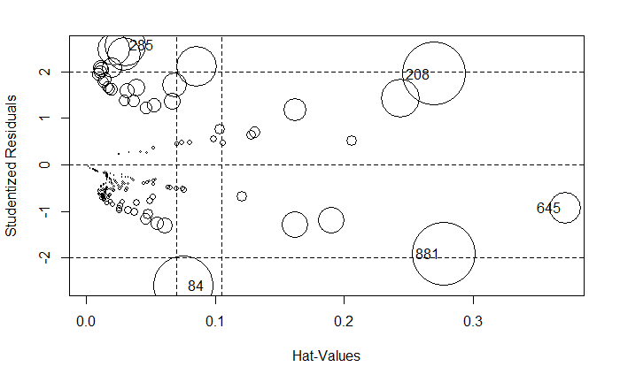

```r
infl <- influencePlot(m5)
```

Here are the exact values of the labeled points. Nothing is too outrageous. A Cook’s D bigger than 1 is the usual red flag. A Hat Value is considered large if it exceeds (2 or 3)(k/n) where k is the number of model coefficients and n is number of observations. Here that comes out to (2 or 3)(7/200) or about (0.07 - 0.11). Residuals larger than 2.5 may be of interest.

```r
infl
```

|  | StudRes | Hat | CookD |
| --- | --- | --- | --- |
| 84 | -2.6003604 | 0.07580765 | 0.18934986 |
| 645 | -0.9388468 | 0.37145410 | 0.05187789 |
| 881 | -1.9263180 | 0.27741452 | 0.20967542 |
| 208 | 1.9489733 | 0.26987455 | 0.21011216 |
| 285 | 2.5699907 | 0.03009097 | 0.08765917 |

We can extract the rownames and use them to subset the icu data frame to see the observed values.

```r
pred <- predict(m5, type = "response")[rownames(infl)]
obs <- icu[rownames(infl), c("died", "age", "cancer",
                             "admit", "uncons", "systolic")]
cbind(obs, pred)
```

|  | died | age | cancer | admit | uncons | systolic | pred |
| --- | --- | --- | --- | --- | --- | --- | --- |
| 84 | No | 59 | No | Emergency | Yes | 48 | 0.93724093 |
| 645 | No | 36 | No | Emergency | No | 224 | 0.27862047 |
| 881 | No | 89 | No | Emergency | Yes | 190 | 0.73421591 |
| 208 | Yes | 70 | No | Elective | Yes | 168 | 0.25606610 |
| 285 | Yes | 40 | No | Emergency | No | 86 | 0.04954614 |

One action to take based on these results is a *sensitivity analysis* where we fit the model without one or more of the data points to see how the model changes. Here’s one way to fit a new model that does not include the influential points identified by `influencePlot`, using `subset = !rownames(icu) %in% rownames(infl)`. Then we compare coefficients from both models.

```r
m5a <- glm(died ~ age + cancer + admit + uncons + systolic + age:systolic,
          data = icu, family = binomial,
          subset = !rownames(icu) %in% rownames(infl))
rbind(before = coef(m5), after = coef(m5a))
```

```
       (Intercept)       age cancerYes admitEmergency unconsYes
before   -13.87749 0.1721072  2.227379       2.938421  3.815361
after    -17.12057 0.2052792  2.763853       3.911508 18.909933
         systolic age:systolic
before 0.05408659 -0.001032180
after  0.06702069 -0.001221676
```

Removing the five influential observations produces larger coefficients and makes the model more dramatic. A conservative approach would be to retain the influential observations since the model is more modest and report the results of the sensitivity analysis.

## References

- Friendly M, Meyer D (2016). Discrete Data Analysis with R: Visualization and Modeling Techniques for Categorical and Count Data. CRC Press.
- Friendly M (2022). *vcdExtra: ‘vcd’ Extensions and Additions*. R package version 0.8-0, https://CRAN.R-project.org/package=vcdExtra.
- Lemeshow, S., Teres, D., Avrunin, J. S., Pastides, H. (1988). Predicting the Outcome of Intensive Care Unit Patients. Journal of the American Statistical Association, 83, 348-356.
- John Fox (2003). Effect Displays in R for Generalised Linear Models. Journal of Statistical Software, 8(15), 1-27. doi 10.18637/jss.v008.i15
- Lüdecke D (2018). “ggeffects: Tidy Data Frames of Marginal Effects from Regression Models.” *Journal of Open Source Software*, *3*(26), 772. doi:10.21105/joss.00772 https://doi.org/10.21105/joss.00772.
- R Core Team (2022). R: A language and environment for statistical computing. R Foundation for Statistical Computing, Vienna, Austria. URL https://www.R-project.org/.